# Solar module I-V

The parameters of a solar panel are given in the table below.

| Parameter | Value |
| --- | --- |
| $P_{max}$ (W) | 320 |
| Voltage at $P_{max}$ (V) | 33.4 |
| Current at $P_{max}$ (A) | 9.59 |
| $V_{OC}$ at STC (V) | 40.9 |
| $I_{SC}$ at STC (A) | 10.15 |
| Temperature coefficient for $I_{SC}$ ($\%/^oC$) | 0.058 |
| Temperature coefficient for $V_{OC}$ ($\%/^oC$) | -0.32 |
| Number of cells in series ($N_C$) | 60 |

Two such panels, along with bypass diodes (assumed to be ideal), are connected in series as shown in the figure. The irradiation for PV1 is $1000\,$W/m$^2$ and that for PV2 is $500\,$W/m$^2$. The load is a current source with $I_S = I_{MPP}$ (the panel current at the maximum power point). Determine the following.

1. currents through the panels PV1 and PV2.
2. currents through the bypass diodes $D_1$ and $D_2$.
3. power delivered to the current source load.

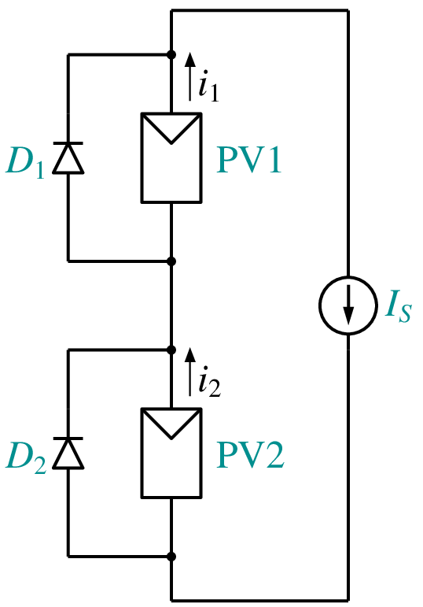

```python
from IPython.display import Image
Image(filename =r'solar_5_fig_1.png', width=180)
```

```python
# run this cell to view the circuit file.
%pycat solar_5_orig.in
```

[output not shown]

We now replace the strings such as \$Voc_ref with the values of our choice by running the python script given below. It takes an existing circuit file `solar_5_orig.in` and produces a new circuit file `solar_5.in`, after replacing \$Voc_ref, etc. with values of our choice.

```python
import gseim_calc as calc

s_g_rad_1 = '1000'
s_g_rad_2 = '500'
s_t_C = '25'
s_Nc = '60'
s_Voc_ref = '40.9'
s_Isc_ref = '10.15'
s_Vm_ref = '33.4'
s_Im_ref = '9.59'
s_coef_Isc = '0.058'
s_coef_Voc = '-0.32'

l = [
  ('$g_rad_1', s_g_rad_1),
  ('$g_rad_2', s_g_rad_2),
  ('$t_C', s_t_C),
  ('$Nc', s_Nc),
  ('$Voc_ref', s_Voc_ref),
  ('$Isc_ref', s_Isc_ref),
  ('$Vm_ref', s_Vm_ref),
  ('$Im_ref', s_Im_ref),
  ('$coef_Isc', s_coef_Isc),
  ('$coef_Voc', s_coef_Voc),
]
calc.replace_strings_1("solar_5_orig.in", "solar_5.in", l)
print('solar_5.in is ready for execution')
```

```
solar_5.in is ready for execution
```

**Execute the following cell to run GSEIM on solar_5.in.**

```python
import os
import dos_unix
# uncomment for windows:
#dos_unix.d2u("solar_5.in")
os.system('run_gseim solar_5.in')
```

```
Circuit: filename = solar_5.in
GSEIM: Program completed.
```

```
0
```

The circuit file (`solar_5.in`) is created in the same directory as that used for launching Jupyter notebook. The last step (i.e., running `GSEIM` on `solar_5.in`) creates a data file called `solar_5.dat` in the same directory. We can now use the python code below to compute/plot the various quantities of interest.

```python
import numpy as np
import matplotlib.pyplot as plt
import gseim_calc as calc
from setsize import set_size

slv = calc.slv("solar_5.in")

i_slv = 0
i_out = 0
filename = slv.l_filename_all[i_slv][i_out]
print('filename:', filename)
u = np.loadtxt(filename)

i1   = slv.get_scalar_double(i_slv,i_out,"i1",u)
i2   = slv.get_scalar_double(i_slv,i_out,"i2",u)
ID1  = slv.get_scalar_double(i_slv,i_out,"ID1",u)
ID2  = slv.get_scalar_double(i_slv,i_out,"ID2",u)
p1   = slv.get_scalar_double(i_slv,i_out,"p1",u)
p2   = slv.get_scalar_double(i_slv,i_out,"p2",u)
v_p  = slv.get_scalar_double(i_slv,i_out,"v_p",u)
P_Is = slv.get_scalar_double(i_slv,i_out,"P_Is",u)

i1_0   = i1
i2_0   = i2
ID1_0  = ID1
ID2_0  = ID2
p1_0   = p1
p2_0   = p2

P_Is_0 = abs(P_Is)

print('IPV1:', "%7.3f"%i1_0, "A")
print('IPV2:', "%7.3f"%i2_0, "A")
print('ID1:', "%7.3f"%ID1_0, "A")
print('ID2:', "%7.3f"%ID2_0, "A")
print('P (PV1):', "%7.3f"%p1_0, "W")
print('P (PV2):', "%7.3f"%p2_0, "W")
print('P (Is):', "%7.3f"%P_Is_0, "W")
```

```
filename: solar_5.dat
IPV1:   9.590 A
IPV2:   5.075 A
ID1:  -0.000 A
ID2:   4.515 A
P (PV1): 320.307 W
P (PV2):  -0.000 W
P (Is): 320.307 W
```

This notebook was contributed by **Prof. Nakul Narayanan K**, Govt. Engineering College, Thrissur. He may be contacted at nakul@gectcr.ac.in.